# Load Fishglob Database and Apply Temporal and Spatial Standardization

- This project is a collaborative effort to describe changes in taxonomic composition of fish communities around the world–as sampled by bottom trawl surveys.
- Code by Zoë J. Kitchel

SESSION INFO

R version 4.2.1 (2022-06-23) Platform: x86_64-apple-darwin17.0 (64-bit) Running under: macOS Big Sur 11.7

Matrix products: default LAPACK: /Library/Frameworks/R.framework/Versions/4.2/Resources/lib/libRlapack.dylib

locale: [1] en_US.UTF-8/en_US.UTF-8/en_US.UTF-8/C/en_US.UTF-8/en_US.UTF-8

attached base packages: [1] stats graphics grDevices utils datasets methods base

other attached packages: [1] cowplot_1.1.1 sf_1.0-9 here_1.0.1 googledrive_2.0.0 [5] geosphere_1.5-14 taxize_0.9.100 rgdal_1.6-2 data.table_1.14.4 [9] rasterVis_0.51.4 lattice_0.20-45 gridExtra_2.3 viridis_0.6.2  
[13] viridisLite_0.4.1 rgbif_3.7.3 rgeos_0.5-9 raster_3.6-11  
[17] sp_1.5-0 tidyr_1.2.1 dplyr_1.0.10

```r
library(dplyr)
library(tidyr)
library(sp)
library(raster)
library(rgeos)
library(rgbif)
library(viridis)
library(gridExtra)
library(rasterVis)
library(concaveman)
set.seed(1)
```

```r
#library(dggridR) #no longer works will find alternate method
library(data.table)
library(rgdal)
library(raster)
library(sp)
#library(rnaturalearth)
#library(rnaturalearthdata)
library(rgeos)
library(taxize) #standardizing names
library(geosphere)  #to calculate distance between lat lon of grid cells
library(googledrive)
library(here)
library(sf)
library(cowplot)
```

Pull in compiled and cleaned data from FishGlob, downloaded on November 28, 2022 (V 1.5) at [this link](https://drive.google.com/file/d/1MgXKhmIufUtjE_Y_mWpDeldJKfd7nDEM/view?usp=share_link). This is typically compiled by Aurore Maureaud.

```r
FishGlob_1.5 <- fread(here::here("data","FISHGLOB_v1.5_clean.csv"))
```

```
|--------------------------------------------------|
|==================================================|
|--------------------------------------------------|
|==================================================|
```

###Because time is an essential component of these analyses, we will get rid of any survey x season combinations that are not sampled for at least 10 years

NB: *NS_IBTS (North Sea) is best examined only for 1st and 3rd quarter (pers communication, Aurore Maureaud)

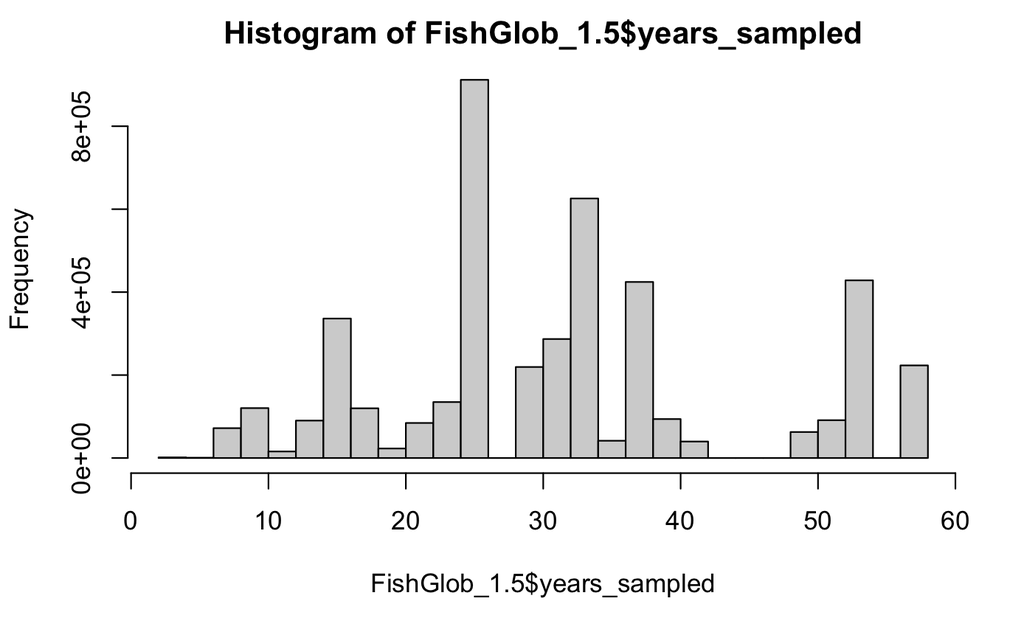

```r
#new row for total number of years sampled
FishGlob_1.5[,years_sampled := length(unique(year)),.(survey_unit)]

hist(FishGlob_1.5$years_sampled)
```

```r
summary(FishGlob_1.5$years_sampled) #ranges from 2 (DFO Straight of Georgia) to 57 (Northeast US)
```

```
   Min. 1st Qu.  Median    Mean 3rd Qu.    Max.
    2.0    25.0    31.0    31.9    37.0    57.0
```

```r
#statistics about full dataset
nrow(FishGlob_1.5) #4,448,187 total observations
```

```
[1] 4448187
```

```r
length(unique(FishGlob_1.5[,survey])) #45 regions
```

```
[1] 45
```

```r
length(unique(FishGlob_1.5[,survey_unit])) #53 unique survey/season combinations
```

```
[1] 53
```

```r
#remove observations for any regions x season combinations sampled less than 10 times
FishGlob.10year <- FishGlob_1.5[years_sampled >= 10,]

#statistics about reduced 10 year dataset
nrow(FishGlob.10year) #4,364,328 total observations (83,859 fewer)
```

```
[1] 4364328
```

```r
length(unique(FishGlob.10year[,survey])) #38 regions (7 fewer)
```

```
[1] 38
```

```r
length(unique(FishGlob.10year[,as.character(survey_unit)])) #45 unique survey/season (8 fewer) combinations
```

```
[1] 45
```

```r
#remove full database
rm(FishGlob_1.5)

#vector with all survey names
all_survey_seasons <- sort(unique(FishGlob.10year[,survey_unit]))
```

###For taxonomic analyses, resolution to species is required. Therefore, we will exclude any observations not resolved to species.

```r
FishGlob.10year.spp <- FishGlob.10year[rank == "Species",] #4,110,764 total observations (253,564 fewer)

#remove full species database
rm(FishGlob.10year)
```

Survey specific changes (These have not actually been implemented as of February 6 2022; standardizations for time and space should catch these)

From Batt et al. 2017 “In the Eastern Bering Sea, sampling years prior to 1984 (data begin in 1982) were excluded from analysis due to large apparent increases in the number of species recorded in the first two years.”

“In the Gulf of Mexico, we restricted our analysis to data from 1984 - 2000 (full range 1982-2014); if all years had been used, the number of sites sampled in at least 85% of years would drop from 39 to 13.”

“In the Southeast U.S., data from 1989 (data begin in 1989) were excluded because several sites were not sampled in this year, and if this year had been used, the number of sites sampled in at least 85% of years would drop from 24 to 23 (with only 21 sites sampled in 1989).”

“In the Northeast U.S., we excluded data from years prior to 1982 (data begin in 1968). Years prior to 1979 were excluded because strata in the southern tip of the region (between approximately 34.5o N and 35o N) were not regularly sampled during this time. A site in the Gulf of Maine (-69.25o E 43.25o N) was not sampled consistently between 1979 and 1981, and including these years in the analysis would have prevented this site from being included in the analysis (which would have reduced total sites from 100 to 99).” #Alexa says start in 1968/1972

“In Newfoundland, years prior to 1996 (first year was 1992) were excluded because many sites were not sampled. If all years had been used (1992 onward), total number of sites sampled in at least 85% of years would have been decreased from 191 to 53; if data from 1995 onward had been included, number of sites would have been 179.”

Maybe throw out last year of triannual survey for West Coast US (overlaps with first)

(Skipping for now, hopefully our cleaning procedure will cover our bases here)

###Standardize observations for all regions

(This is preliminary code where we use threshold of 70% observation coverage for getting rid of years and n = 1/year for keeping cells)

At some point in the near future, I will just use Laura’s code here, or perhaps her final data product where we eliminate observations that don’t match consistent spatial footprint but limit whether this happens in years or locations by # of observations lost.

####Edit function to create grid From [here](https://strimas.com/post/hexagonal-grids/)

We will use cell size of 7,774.2 km^2, as that will match grid cell size of 8 in dggridr. We can’t use the package dggridr unfortunately because it doesn’t work for this version of R (and others have had this issue too). https://github.com/r-barnes/dggridR For Norway (?) we will use cell size of 23,322.2 km^2 because the sites are further away from each other.